# UK: Household size model

# Isolating the outcome variable

```python
#selecting the dependent variable
y=data['hhsize']
```

```python
#displaying the five rows of our dependent variable
y.head()
```

```
0    0
1    1
2    0
3    1
4    0
Name: hhsize, dtype: int32
```

# Selecting the fetaures

```python
#selecting independent variable x by dropping the dependent variable
x=data.drop('hhsize', axis=1)
```

```python
#displaying the first five rows of our independent variable
x.head()
```

|  | sex | age | region | mastat | hushop | lstage | nkids | parent | chzerotothree | chfourtofive | ... | qual | jbstat | jbrgsc | hoh | jbstathoh | fihhyrtwo | us | mghave | intmg | dfihhyr |
| --- | --- | --- | --- | --- | --- | --- | --- | --- | --- | --- | --- | --- | --- | --- | --- | --- | --- | --- | --- | --- | --- |
| 0 | 0 | 29.0 | 4 | 2 | 1 | 4 | 0 | 0 | 0 | 0 | ... | 2 | 6 | 3 | 1 | 6 | 2 | 1 | 0 | 6 | 3 |
| 1 | 0 | 43.0 | 4 | 1 | 0 | 0 | 2 | 1 | 0 | 0 | ... | 0 | 1 | 1 | 1 | 1 | 15 | 2 | 2 | 5 | 16 |
| 2 | 0 | 53.0 | 10 | 1 | 0 | 2 | 0 | 0 | 0 | 0 | ... | 4 | 1 | 3 | 1 | 1 | 8 | 2 | 2 | 5 | 12 |
| 3 | 0 | 36.0 | 7 | 1 | 0 | 0 | 2 | 1 | 1 | 0 | ... | 7 | 1 | 3 | 1 | 1 | 11 | 2 | 2 | 1 | 16 |
| 4 | 1 | 63.0 | 9 | 1 | 1 | 2 | 0 | 0 | 0 | 0 | ... | 1 | 3 | 1 | 1 | 3 | 2 | 2 | 0 | 6 | 3 |

5 rows × 22 columns

# Modelling Approach A: Naive Bayes Classifier

# Importing of the packages for Naive Bayes Classifier, Decision Tree and Random forest.

```python
#importing of the packages
from sklearn.model_selection import train_test_split
from sklearn.naive_bayes import GaussianNB
from sklearn.tree import DecisionTreeClassifier
from sklearn.ensemble import RandomForestClassifier
from sklearn.metrics import accuracy_score
from sklearn.preprocessing import StandardScaler, MinMaxScaler
import pandas_profiling

from matplotlib import rcParams
import warnings

warnings.filterwarnings("ignore")

# figure size in inches
rcParams["figure.figsize"] = 10, 6
np.random.seed(42)
```

```python
#scaling the datasets
scaler = StandardScaler()
x_scaled = scaler.fit_transform(x)
```

```python
# split into train and test set
x_train, x_test, y_train, y_test = train_test_split(x_scaled, y, stratify=y, test_size=0.10, random_state=42)
```

# Modelling Approach A: Using Naive Bayes Classifier

```python
#Creating the classifier
model = GaussianNB()
model.fit(x_train, y_train);
```

```python
#importing the metrics
from sklearn.metrics import (
    accuracy_score, precision_score, recall_score,
    confusion_matrix,
    ConfusionMatrixDisplay,
    f1_score,
    classification_report,
)
#setting the y_pred
y_pred = model.predict(x_test)
#setting and printing the accuracy
accuracy = accuracy_score(y_pred, y_test)
precision=precision_score(y_pred, y_test,average="weighted")
recall=recall_score(y_pred, y_test, average="weighted")
f1 = f1_score(y_pred, y_test, average="weighted")
```

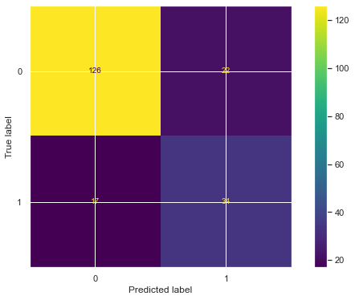

```python
#Computing values for confusion matrix
NaiveBayes_cm = confusion_matrix(y_test, y_pred, labels=model.classes_)

# Creating a display of confusion matrix
NaiveBayes_disp = ConfusionMatrixDisplay(confusion_matrix=NaiveBayes_cm,
                                  display_labels=model.classes_)

# Plotting a confusion matrix
NaiveBayes_disp.plot(values_format='')

# Displaying a plot
plt.show()
```

```python
print("Accuracy:", accuracy)
print("F1 Score:", f1)
print("Precision:", precision)
print("Recall:", recall)
```

```
Accuracy: 0.8040201005025126
F1 Score: 0.8011248070006066
Precision: 0.7993797817918421
Recall: 0.8040201005025126
```

# Feature importance of Naive Bayes Classifier:

```python
from sklearn.naive_bayes import GaussianNB
from sklearn.model_selection import train_test_split
from sklearn.metrics import accuracy_score
from sklearn.inspection import permutation_importance

# Split your data into training and testing sets
x_train, x_test, y_train, y_test = train_test_split(x, y, test_size=0.2, random_state=42)

# Fit a Gaussian Naive Bayes model
model = GaussianNB()
model.fit(x_train, y_train)

# Calculate the permutation importance
perm_importance = permutation_importance(model, x_test, y_test, n_repeats=30, random_state=42)

# Print the results
for i in range(len(x_test.columns)):
    print(f"Feature {x_test.columns[i]} importance: {perm_importance.importances_mean[i]}")
```

```
Feature sex importance: 0.0
Feature age importance: -0.005541561712846299
Feature region importance: 0.0
Feature mastat importance: -0.0009235936188076832
Feature hushop importance: 0.0010075566750630187
Feature lstage importance: 0.003862300587741452
Feature nkids importance: 0.049958018471872416
Feature parent importance: -0.00193115029387065
Feature chzerotothree importance: -0.018807724601175427
Feature chfourtofive importance: 0.02762384550797653
Feature chsixtonine importance: 0.02712006717044504
Feature chtentofifteen importance: 0.03064651553316544
Feature qual importance: 0.0003358522250210346
Feature jbstat importance: -0.0010075566750629595
Feature jbrgsc importance: 2.590520390792032e-17
Feature hoh importance: -0.0011754827875734306
Feature jbstathoh importance: 0.00025188916876577315
Feature fihhyrtwo importance: -8.396305625524662e-05
Feature us importance: -0.0010075566750629595
Feature mghave importance: -0.002938706968933628
Feature intmg importance: -0.003190596137699364
Feature dfihhyr importance: -0.0019311502938706723
```

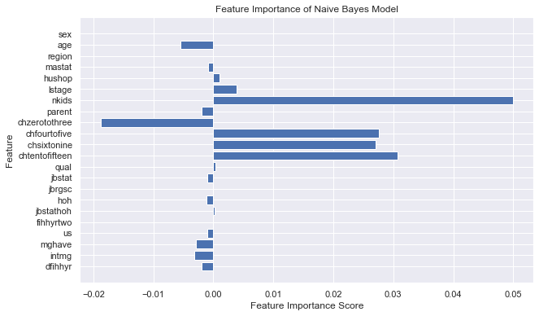

```python
# Feature selection or ranking code (use your chosen method)
selected_features = ["sex", "age", "region", "mastat","hushop", "lstage","nkids","parent","chzerotothree","chfourtofive",
                     " chsixtonine","chtentofifteen","qual","jbstat","jbrgsc","hoh","jbstathoh","fihhyrtwo","us","mghave",
                     "intmg","dfihhyr"]
feature_importance_scores = [0.0, -0.005541561712846299, 0.0,-0.0009235936188076832, 0.0010075566750630187,0.003862300587741452,
                            0.049958018471872416,-0.00193115029387065,-0.018807724601175427, 0.02762384550797653,0.02712006717044504,
                            0.03064651553316544,0.0003358522250210346,-0.0010075566750629595,2.590520390792032e-17,-0.0011754827875734306,
                            0.00025188916876577315,-8.396305625524662e-05,-0.0010075566750629595,-0.002938706968933628,-0.003190596137699364,
                            -0.0019311502938706723]

# Create a horizontal bar chart
plt.figure(figsize=(10, 6))
plt.barh(selected_features, feature_importance_scores)
plt.xlabel("Feature Importance Score")
plt.ylabel("Feature")
plt.title("Feature Importance of Naive Bayes Model")
plt.gca().invert_yaxis()  # Invert the y-axis for better readability
plt.show()
```

# The Roc Curve of Naive Bayes Classifier

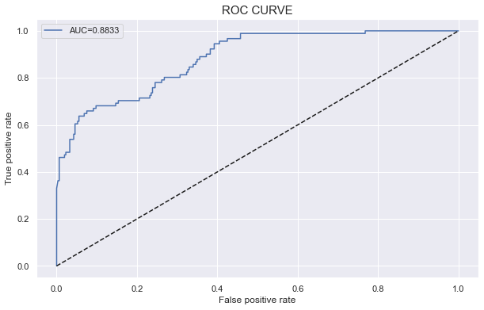

```python
y_pred_proba = model.predict_proba(x_test)[:, 1]

data_actual_predicted = pd.concat([pd.DataFrame(np.array(y_test), columns=['y_actual']),
                                   pd.DataFrame(y_pred_proba, columns=['y_predicted'])],
                                  axis=1)

fpr, tpr, thresholds = roc_curve(data_actual_predicted['y_actual'], data_actual_predicted['y_predicted'])
auc = roc_auc_score(data_actual_predicted['y_actual'], data_actual_predicted['y_predicted'])

plt.plot(fpr, tpr, label='AUC=%0.4f' % auc)
plt.plot([0, 1], [0, 1], linestyle='--', color='k')
plt.xlabel('False positive rate')
plt.ylabel('True positive rate')
plt.title('ROC CURVE', size=15)
plt.legend()
plt.show()
```

# Decision Tree: Standard form

```python
#importing the decision tree classifier
from sklearn.tree import DecisionTreeClassifier
```

```python
# create the classifier
DecisionTree = DecisionTreeClassifier(random_state=100)

# Train the model using the training sets
DecisionTree.fit(x_train, y_train)
```

```
DecisionTreeClassifier(random_state=100)
```

```python
# predictin on the test set
y_pred = DecisionTree.predict(x_test)
```

```python
# Calculate Model Accuracy
print("Accuracy:", accuracy_score(y_test, y_pred))
```

```
Accuracy: 0.8161209068010076
```

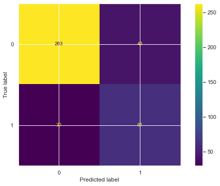

```python
 #Computing values for confusion matrix
DecisionTree_cm= confusion_matrix(y_test, y_pred, labels=DecisionTree.classes_)

# Creating a display of confusion matrix
DecisionTree_disp = ConfusionMatrixDisplay(confusion_matrix=DecisionTree_cm,
                                  display_labels=DecisionTree.classes_)

# Plotting a confusion matrix
DecisionTree_disp.plot(values_format='')

# Displaying a plot
plt.show()
```

```python
#printing the classification report
target_names = ['Predicted as small household', 'Predicted as big household']
print(classification_report(y_test, y_pred, target_names=target_names))
```

```
                              precision    recall  f1-score   support

Predicted as small household       0.90      0.86      0.88       306
  Predicted as big household       0.59      0.67      0.63        91

                    accuracy                           0.82       397
                   macro avg       0.74      0.76      0.75       397
                weighted avg       0.83      0.82      0.82       397
```

```python
# check Important features
feature_importances_df = pd.DataFrame(
    {"feature": list(x.columns), "importance": DecisionTree.feature_importances_}
).sort_values("importance", ascending=False)

# Display
feature_importances_df
```

|  | feature | importance |
| --- | --- | --- |
| 6 | nkids | 0.487057 |
| 1 | age | 0.130870 |
| 2 | region | 0.066327 |
| 21 | dfihhyr | 0.048287 |
| 3 | mastat | 0.041280 |
| 17 | fihhyrtwo | 0.038299 |
| 15 | hoh | 0.030084 |
| 14 | jbrgsc | 0.029500 |
| 12 | qual | 0.024063 |
| 4 | hushop | 0.023779 |
| 18 | us | 0.015962 |
| 11 | chtentofifteen | 0.014194 |
| 13 | jbstat | 0.012387 |
| 20 | intmg | 0.008160 |
| 19 | mghave | 0.006654 |
| 16 | jbstathoh | 0.006502 |
| 9 | chfourtofive | 0.005607 |
| 8 | chzerotothree | 0.002942 |
| 5 | lstage | 0.002759 |
| 7 | parent | 0.002532 |
| 0 | sex | 0.002350 |
| 10 | chsixtonine | 0.000404 |

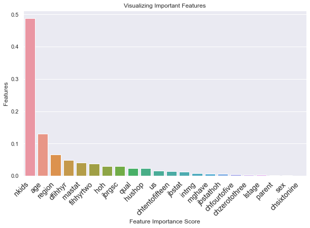

```python
# visualize important featuers

# Creating a bar plot
sns.barplot(x=feature_importances_df.feature, y=feature_importances_df.importance)
# Add labels to your

plt.xlabel("Feature Importance Score")
plt.ylabel("Features")
plt.title("Visualizing Important Features")
plt.xticks(
    rotation=45, horizontalalignment="right", fontweight="light", fontsize="x-large"
)
plt.show()
```

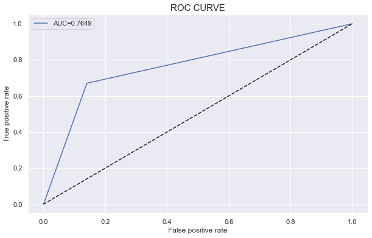

```python
y_pred_proba = DecisionTree.predict_proba(x_test)[:, 1]

data_actual_predicted = pd.concat([pd.DataFrame(np.array(y_test), columns=['y_actual']),
                                   pd.DataFrame(y_pred_proba, columns=['y_predicted'])],
                                  axis=1)

fpr, tpr, thresholds = roc_curve(data_actual_predicted['y_actual'], data_actual_predicted['y_predicted'])
auc = roc_auc_score(data_actual_predicted['y_actual'], data_actual_predicted['y_predicted'])

plt.plot(fpr, tpr, label='AUC=%0.4f' % auc)
plt.plot([0, 1], [0, 1], linestyle='--', color='k')
plt.xlabel('False positive rate')
plt.ylabel('True positive rate')
plt.title('ROC CURVE', size=15)
plt.legend()
plt.show()
```

# Modelling Approach B: Tree-Based Model using Standard Method:

# Random Forest: Standard Method

```python
# create the classifier
classifier = RandomForestClassifier(n_estimators=100)

# Train the model using the training sets
classifier.fit(x_train, y_train)
```

```
RandomForestClassifier()
```

```python
# predictin on the test set
y_pred = classifier.predict(x_test)
```

```python
# Calculate Model Accuracy
print("Accuracy:", accuracy_score(y_test, y_pred))
```

```
Accuracy: 0.906801007556675
```

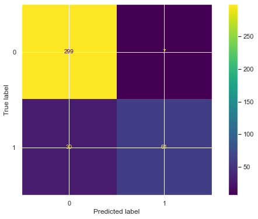

```python
 #Computing values for confusion matrix
rfc_cm = confusion_matrix(y_test, y_pred, labels=classifier.classes_)

# Creating a display of confusion matrix
rfc_disp = ConfusionMatrixDisplay(confusion_matrix=rfc_cm,
                                  display_labels=classifier.classes_)

# Plotting a confusion matrix
rfc_disp.plot(values_format='')

# Displaying a plot
plt.show()
```

# Classification Report

```python
from sklearn.metrics import classification_report
```

```python
# Create classification report for random forest model
target_names = ['Predicted as small household', 'Predicted as big household']
print(classification_report(y_test, y_pred, target_names=target_names))
```

```
                              precision    recall  f1-score   support

Predicted as small household       0.91      0.98      0.94       306
  Predicted as big household       0.90      0.67      0.77        91

                    accuracy                           0.91       397
                   macro avg       0.90      0.82      0.85       397
                weighted avg       0.91      0.91      0.90       397
```

# Feature importance

```python
# check Important features
feature_importances_df = pd.DataFrame(
    {"feature": list(x.columns), "importance": classifier.feature_importances_}
).sort_values("importance", ascending=False)

# Display
feature_importances_df
```

|  | feature | importance |
| --- | --- | --- |
| 6 | nkids | 0.184730 |
| 1 | age | 0.127950 |
| 5 | lstage | 0.093016 |
| 7 | parent | 0.068106 |
| 11 | chtentofifteen | 0.049625 |
| 2 | region | 0.047848 |
| 21 | dfihhyr | 0.045987 |
| 17 | fihhyrtwo | 0.044134 |
| 12 | qual | 0.037063 |
| 3 | mastat | 0.036086 |
| 14 | jbrgsc | 0.034983 |
| 13 | jbstat | 0.032171 |
| 16 | jbstathoh | 0.028578 |
| 10 | chsixtonine | 0.025975 |
| 15 | hoh | 0.023180 |
| 9 | chfourtofive | 0.021158 |
| 18 | us | 0.020956 |
| 4 | hushop | 0.020799 |
| 19 | mghave | 0.016477 |
| 20 | intmg | 0.016055 |
| 0 | sex | 0.013757 |
| 8 | chzerotothree | 0.011367 |

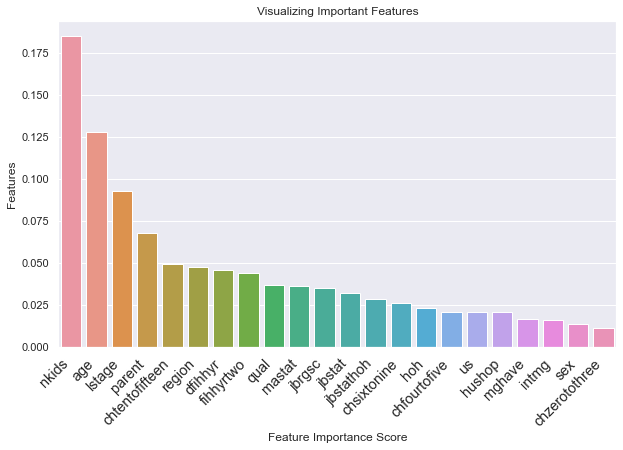

```python
# visualize important featuers

# Creating a bar plot
sns.barplot(x=feature_importances_df.feature, y=feature_importances_df.importance)
# Add labels to your

plt.xlabel("Feature Importance Score")
plt.ylabel("Features")
plt.title("Visualizing Important Features")
plt.xticks(
    rotation=45, horizontalalignment="right", fontweight="light", fontsize="x-large"
)
plt.show()
```

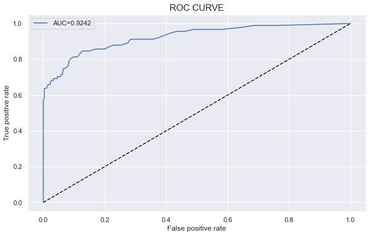

```python
y_pred_proba = classifier.predict_proba(x_test)[:, 1]

data_actual_predicted = pd.concat([pd.DataFrame(np.array(y_test), columns=['y_actual']),
                                   pd.DataFrame(y_pred_proba, columns=['y_predicted'])],
                                  axis=1)

fpr, tpr, thresholds = roc_curve(data_actual_predicted['y_actual'], data_actual_predicted['y_predicted'])
auc = roc_auc_score(data_actual_predicted['y_actual'], data_actual_predicted['y_predicted'])

plt.plot(fpr, tpr, label='AUC=%0.4f' % auc)
plt.plot([0, 1], [0, 1], linestyle='--', color='k')
plt.xlabel('False positive rate')
plt.ylabel('True positive rate')
plt.title('ROC CURVE', size=15)
plt.legend()
plt.show()
```

# Modelling Approach C: Tree-Based Model using GridSearchCV Method

This approach covers implementation of Decision Tree and Random Forest

# Decision Tree: GridSearchCV

```python
#importing package GridSearchCV
from sklearn.model_selection import GridSearchCV
```

```python
dtree=DecisionTreeClassifier(class_weight='balanced')
param_grid={
    'max_depth':[3,4,5,6,7,8],
    'min_samples_split':[2,3,4],
    'min_samples_leaf':[1,2,3,4],
    'random_state':[0,42]

}
grid_search=GridSearchCV(dtree, param_grid, cv=5)
grid_search.fit(x_train, y_train)
print(grid_search.best_params_)
```

```
{'max_depth': 5, 'min_samples_leaf': 1, 'min_samples_split': 2, 'random_state': 0}
```

```python
from sklearn.tree import DecisionTreeClassifier
dtree=DecisionTreeClassifier(random_state=0, max_depth=7, min_samples_leaf=3, min_samples_split=2, class_weight='balanced')
dtree.fit(x_train, y_train)
```

```
DecisionTreeClassifier(class_weight='balanced', max_depth=7, min_samples_leaf=3,
                       random_state=0)
```

```python
from sklearn.metrics import accuracy_score
y_pred=dtree.predict(x_test)
print("Accuracy Score:", round(accuracy_score(y_test, y_pred)*100,2),"%")
```

```
Accuracy Score: 87.91 %
```

```python
from sklearn.metrics import accuracy_score, precision_score, recall_score, f1_score, jaccard_score, log_loss
print('F_1 Score:',(f1_score(y_test, y_pred, average='weighted')))
print('Precision Score:', (precision_score(y_test, y_pred, average='weighted')))
print('Recall Score:', (recall_score(y_test, y_pred, average='weighted')))
print('Jaccard Score:', (jaccard_score(y_test, y_pred, average='weighted')))
print('Log Loss:',(log_loss(y_test, y_pred)))
```

```
F_1 Score: 0.8786184111564201
Precision Score: 0.8782002109061796
Recall Score: 0.8790931989924433
Jaccard Score: 0.7917118089919907
Log Loss: 4.176019288908331
```

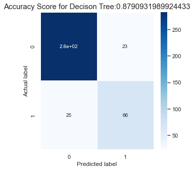

```python
from sklearn.metrics import confusion_matrix
cm=confusion_matrix(y_test, y_pred)
plt.figure(figsize=(5,5))
sns.heatmap(data=cm, linewidths=.5, annot=True, cmap='Blues')
plt.ylabel('Actual label')
plt.xlabel('Predicted label')
all_sample_title='Accuracy Score for Decison Tree:{0}'. format(dtree.score(x_test, y_test))
plt.title(all_sample_title, size=15)
```

# Feature Importance of the Decision Tree

```python
# check Important features
feature_importances_df = pd.DataFrame(
    {"feature": list(x.columns), "importance": dtree.feature_importances_}
).sort_values("importance", ascending=False)

# Display
feature_importances_df
```

|  | feature | importance |
| --- | --- | --- |
| 6 | nkids | 0.569373 |
| 1 | age | 0.225604 |
| 3 | mastat | 0.042670 |
| 21 | dfihhyr | 0.034350 |
| 15 | hoh | 0.032707 |
| 11 | chtentofifteen | 0.023422 |
| 5 | lstage | 0.013310 |
| 2 | region | 0.012450 |
| 13 | jbstat | 0.010245 |
| 4 | hushop | 0.006045 |
| 16 | jbstathoh | 0.005388 |
| 18 | us | 0.005310 |
| 14 | jbrgsc | 0.004468 |
| 8 | chzerotothree | 0.003470 |
| 17 | fihhyrtwo | 0.002677 |
| 0 | sex | 0.002289 |
| 12 | qual | 0.002143 |
| 19 | mghave | 0.002076 |
| 20 | intmg | 0.002003 |
| 7 | parent | 0.000000 |
| 9 | chfourtofive | 0.000000 |
| 10 | chsixtonine | 0.000000 |

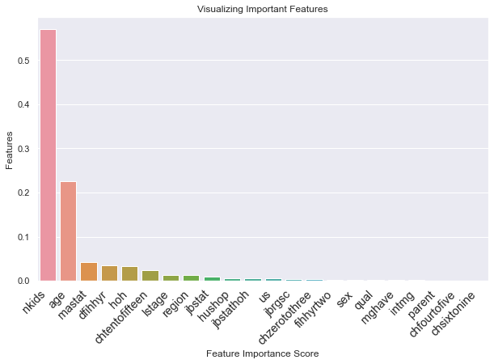

```python
# visualize important featurers

# Creating a bar plot
sns.barplot(x=feature_importances_df.feature, y=feature_importances_df.importance)
# Add labels to your

plt.xlabel("Feature Importance Score")
plt.ylabel("Features")
plt.title("Visualizing Important Features")
plt.xticks(
    rotation=45, horizontalalignment="right", fontweight="light", fontsize="x-large"
)
plt.show()
```

# The Roc Curve of the Decision Tree

```python
from sklearn.metrics import  roc_auc_score, roc_curve
```

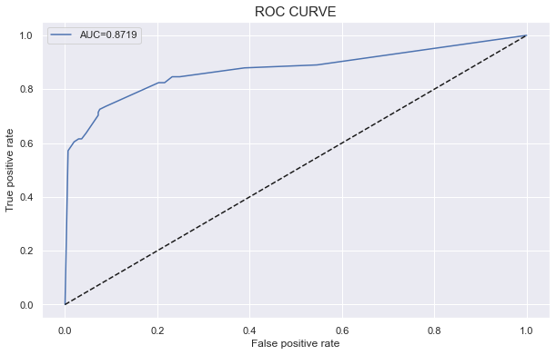

```python
y_pred_proba = dtree.predict_proba(x_test)[:, 1]

data_actual_predicted = pd.concat([pd.DataFrame(np.array(y_test), columns=['y_actual']),
                                   pd.DataFrame(y_pred_proba, columns=['y_predicted'])],
                                  axis=1)

fpr, tpr, thresholds = roc_curve(data_actual_predicted['y_actual'], data_actual_predicted['y_predicted'])
auc = roc_auc_score(data_actual_predicted['y_actual'], data_actual_predicted['y_predicted'])

plt.plot(fpr, tpr, label='AUC=%0.4f' % auc)
plt.plot([0, 1], [0, 1], linestyle='--', color='k')
plt.xlabel('False positive rate')
plt.ylabel('True positive rate')
plt.title('ROC CURVE', size=15)
plt.legend()
plt.show()
```

# Random Forest: GridSearchCV

```python
from sklearn.ensemble import RandomForestClassifier
from sklearn.model_selection import GridSearchCV
rfc=RandomForestClassifier(class_weight='balanced')
param_grid={
    'n_estimators':[100,200],
    'max_depth':[None, 5, 10],
    'max_features':['sqrt', 'log2', None],
    'random_state':[0, 42]
}
grid_search=GridSearchCV(rfc, param_grid, cv=5)
grid_search.fit(x_train, y_train)
print(grid_search.best_params_)
```

```
{'max_depth': None, 'max_features': 'sqrt', 'n_estimators': 200, 'random_state': 0}
```

```python
from sklearn.ensemble import RandomForestClassifier
rfc=RandomForestClassifier(random_state=42, max_depth=10, max_features='sqrt', n_estimators=200)
rfc.fit(x_train, y_train)
```

```
RandomForestClassifier(max_depth=10, max_features='sqrt', n_estimators=200,
                       random_state=42)
```

```python
y_pred=rfc.predict(x_test)
print("Accuracy Score:", round(accuracy_score(y_test, y_pred)*100,2),"%")
```

```
Accuracy Score: 90.93 %
```

```python
from sklearn.metrics import accuracy_score, precision_score, recall_score, f1_score, jaccard_score, log_loss
print('F_1 Score:',(f1_score(y_test, y_pred, average='weighted')))
print('Precision Score:', (precision_score(y_test, y_pred, average='weighted')))
print('Recall Score:', (recall_score(y_test, y_pred, average='weighted')))
print('Jaccard Score:', (jaccard_score(y_test, y_pred, average='weighted')))
print('Log Loss:',(log_loss(y_test, y_pred)))
```

```
F_1 Score: 0.9041437482816851
Precision Score: 0.9094019255679467
Recall Score: 0.9093198992443325
Jaccard Score: 0.8323453144533931
Log Loss: 3.131991808063894
```

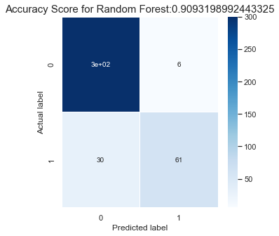

```python
from sklearn.metrics import confusion_matrix
cm=confusion_matrix(y_test, y_pred)
plt.figure(figsize=(5,5))
sns.heatmap(data=cm, linewidths=.5, annot=True, cmap='Blues')
plt.ylabel('Actual label')
plt.xlabel('Predicted label')
all_sample_title='Accuracy Score for Random Forest:{0}'. format(rfc.score(x_test, y_test))
plt.title(all_sample_title, size=15)
```

# Feature Importance of the Random Forest

```python
# check Important features
feature_importances_df = pd.DataFrame(
    {"feature": list(x.columns), "importance": rfc.feature_importances_}
).sort_values("importance", ascending=False)

# Display
feature_importances_df
```

|  | feature | importance |
| --- | --- | --- |
| 6 | nkids | 0.226237 |
| 1 | age | 0.118262 |
| 5 | lstage | 0.109315 |
| 7 | parent | 0.069836 |
| 11 | chtentofifteen | 0.052678 |
| 3 | mastat | 0.037721 |
| 2 | region | 0.037391 |
| 17 | fihhyrtwo | 0.036045 |
| 21 | dfihhyr | 0.034872 |
| 10 | chsixtonine | 0.033056 |
| 13 | jbstat | 0.031288 |
| 16 | jbstathoh | 0.031018 |
| 12 | qual | 0.027817 |
| 14 | jbrgsc | 0.027285 |
| 9 | chfourtofive | 0.025316 |
| 15 | hoh | 0.020462 |
| 4 | hushop | 0.018032 |
| 18 | us | 0.016951 |
| 19 | mghave | 0.012806 |
| 20 | intmg | 0.012175 |
| 8 | chzerotothree | 0.012023 |
| 0 | sex | 0.009414 |

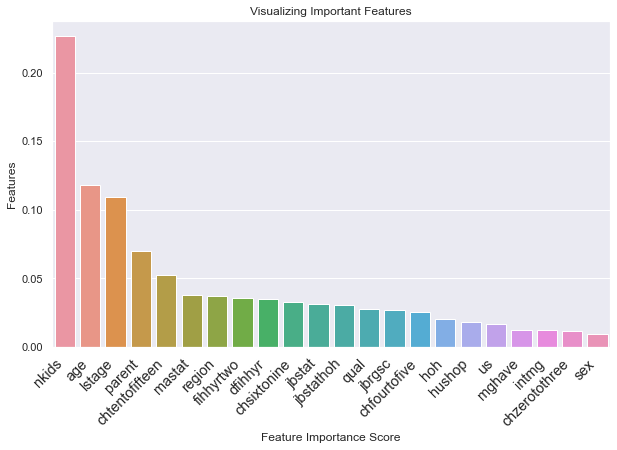

```python
# visualize important featuers

# Creating a bar plot
sns.barplot(x=feature_importances_df.feature, y=feature_importances_df.importance)
# Add labels to your

plt.xlabel("Feature Importance Score")
plt.ylabel("Features")
plt.title("Visualizing Important Features")
plt.xticks(
    rotation=45, horizontalalignment="right", fontweight="light", fontsize="x-large"
)
plt.show()
```

# The Roc Curve of the Random Forest

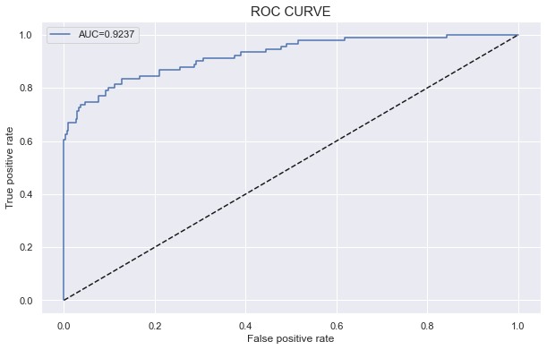

```python
y_pred_proba = rfc.predict_proba(x_test)[:, 1]

data_actual_predicted = pd.concat([pd.DataFrame(np.array(y_test), columns=['y_actual']),
                                   pd.DataFrame(y_pred_proba, columns=['y_predicted'])],
                                  axis=1)

fpr, tpr, thresholds = roc_curve(data_actual_predicted['y_actual'], data_actual_predicted['y_predicted'])
auc = roc_auc_score(data_actual_predicted['y_actual'], data_actual_predicted['y_predicted'])

plt.plot(fpr, tpr, label='AUC=%0.4f' % auc)
plt.plot([0, 1], [0, 1], linestyle='--', color='k')
plt.xlabel('False positive rate')
plt.ylabel('True positive rate')
plt.title('ROC CURVE', size=15)
plt.legend()
plt.show()
```

# Summary of model results:

# Naive Bayes Classifier:

The naive bayes model achieved precision of 80% , recall of 80%, f1_score of 80% (all weighted averages), accuracy of 80% on the test set and AUC of 88%

# Tree_based Model: Standard Method:

The decision tree achieved precision of 83% , recall of 82%, f1_score of 82% (all weighted averages), and an accuracy of 82% on the test set AUC of 76%

The random forest has achieved precision of 91%, f1_score=90%, recall of 91% (all weighted averages), accuracy of 91% on the test set, and an AUC of 92%

# Tree-Based Model: GridSearchCV Method:

The decision tree achieved precision of 88%, recall of 88%, f1_score of 87% (all weighted averages) accuracy of 87% on the test set and an AUC of 87%

The random forest has achieved precision of 91%, f1_score=90%, recall of 91% (all weighted averages) accuracy of 91% on the test set and an AUC of 92%

# Feature importance explained

The are five machine learning models that have been in this project, the naive bayes classifier, decision tree classifier the standard form, random forest the standard form, decision tree GridSearchCV and random forest GridSearchCV. The variable nkids in all machine learning models is the most import in predicting the household size in the United Kingdom. The more the nkids in a household the bigger the family size and vise versa. One of the variables that is playing important role is the machine learning models used besides the naive bayes classifier is the age variable. This means that the greater the age of the people in this survey, the greater the chances of them having kids, and on the other hand increasing the sizes of the households.

# The best model to forecast household size in the UK

From the results we obtained above, we can see that the random forest (standard method) and random forest (GridSearch Method) produce the best results. Infact these two methods produced same results and one of the two methods is the best forcasting household size in the UK. The accuracies of these methods are 91% and AUCs are 92% which is quite remarkable. The other methods namely naive bayes classifier, the decision tree classifier (standard method), decision tree classifier (GridSearch Method) produced lower accuracies and AUCs respectively.